# Modern Data Mining, HW 4

Diego G. Dávila

Margaret Gardner

Joelle Bagautdinova

11:59 pm, 03/20, 2021

# 1 Overview

Logistic regression is used for modeling categorical response variables. The simplest scenario is how to identify risk factors of heart disease? In this case the response takes a possible value of `YES` or `NO`. Logit link function is used to connect the probability of one being a heart disease with other potential risk factors such as `blood pressure`, `cholestrol level`, `weight`. Maximum likelihood function is used to estimate unknown parameters. Inference is made based on the properties of MLE. We use AIC to help nailing down a useful final model. Predictions in categorical response case is also termed as `Classification` problems. One immediately application of logistic regression is to provide a simple yet powerful classification boundaries. Various metrics/criteria are proposed to evaluate the quality of a classification rule such as `False Positive`, `FDR` or `Mis-Classification Errors`.

LASSO with logistic regression is a powerful tool to get dimension reduction.

## 1.1 Objectives

- Understand the model
  - logit function
    - interpretation
  - Likelihood function
- Methods
  - Maximum likelihood estimators
    - Z-intervals/tests
    - Chi-squared likelihood ratio tests
- Metrics/criteria
  - Sensitivity/False Positive
  - True Positive Prediction/FDR
  - Misclassification Error/Weighted MCE
  - Residual deviance
  - Training/Testing errors
- LASSO
- R functions/Packages
  - `glm()`, `Anova`
  - `pROC`
  - `cv.glmnet`

## 1.2 R Markdown / Knitr tips

You should think of this R Markdown file as generating a polished report, one that you would be happy to show other people (or your boss). There shouldn’t be any extraneous output; all graphs and code run should clearly have a reason to be run. That means that any output in the final file should have explanations.

A few tips:

- Keep each chunk to only output one thing! In R, if you’re not doing an assignment (with the `<-` operator), it’s probably going to print something.
- If you don’t want to print the R code you wrote (but want to run it, and want to show the results), use a chunk declaration like this: `{r, echo=F}`. Notice this is set as a global option.
- If you don’t want to show the results of the R code or the original code, use a chunk declaration like: `{r, include=F}`
- If you don’t want to show the results, but show the original code, use a chunk declaration like: `{r, results='hide'}`.
- If you don’t want to run the R code at all use `{r, eval = F}`.
- We show a few examples of these options in the below example code.
- For more details about these R Markdown options, see the [documentation](http://yihui.name/knitr/options/).
- Delete the instructions and this R Markdown section, since they’re not part of your overall report.

## 1.3 Review

Review the code and concepts covered in

- Module Logistic Regressions/Classification
- Module LASSO in Logistic Regression

## 1.4 This homework

We have two parts in this homework. Part I is guided portion of work, designed to get familiar with elements of logistic regressions/classification. Part II, we bring you projects. You have options to choose one topic among either Credit Risk via LendingClub or Diabetes and Health Management. Find details in the projects.

# 2 Part I: Framingham heart disease study

We will continue to use the Framingham Data (`Framingham.dat`) so that you are already familiar with the data and the variables. All the results are obtained through training data.

Liz is a patient with the following readings: `AGE=50, GENDER=FEMALE, SBP=110, DBP=80, CHOL=180, FRW=105, CIG=0`. We would be interested to predict Liz’s outcome in heart disease.

To keep our answers consistent, use a subset of the data, and exclude anyone with a missing entry. For your convenience, we’ve loaded it here together with a brief summary about the data.

We note that this dataset contains 311 people diagnosed with heart disease and 1095 without heart disease.

```
     0    1
  1095  311
```

After a quick cleaning up here is a summary about the data:

```
       HD            AGE           SEX           SBP           DBP
       0:1086   Min.   :45.0   FEMALE:730   Min.   : 90   Min.   : 50.0
       1: 307   1st Qu.:48.0   MALE  :663   1st Qu.:130   1st Qu.: 80.0
                Median :52.0                Median :142   Median : 90.0
                Mean   :52.4                Mean   :148   Mean   : 90.2
                3rd Qu.:56.0                3rd Qu.:160   3rd Qu.: 98.0
                Max.   :62.0                Max.   :300   Max.   :160.0
            CHOL          FRW           CIG
       Min.   : 96   Min.   : 52   Min.   : 0
       1st Qu.:200   1st Qu.: 94   1st Qu.: 0
       Median :230   Median :103   Median : 0
       Mean   :235   Mean   :105   Mean   : 8
       3rd Qu.:264   3rd Qu.:114   3rd Qu.:20
       Max.   :430   Max.   :222   Max.   :60
```

```
           HD AGE    SEX SBP DBP CHOL FRW CIG
      1017  0  52 FEMALE 152  90  207 108   0
      679   0  46 FEMALE 116  70  237  93   0
      129   0  46   MALE 154 100  145 107   0
      930   0  53 FEMALE 125  85  255  74   0
      471   0  55   MALE 136  96  250 102   0
```

```
           HD AGE    SEX SBP DBP CHOL FRW CIG
      1017  0  52 FEMALE 152  90  207 108   0
      679   0  46 FEMALE 116  70  237  93   0
      129   0  46   MALE 154 100  145 107   0
      930   0  53 FEMALE 125  85  255  74   0
      471   0  55   MALE 136  96  250 102   0
```

## 2.1 Identify risk factors

### 2.1.1 Understand the likelihood function

Conceptual questions to understand the building blocks of logistic regression. All the codes in this part should be hidden. We will use a small subset to run a logistic regression of `HD` vs. `SBP`.

1. Take a random subsample of size 5 from `hd_data_f` which only includes `HD` and `SBP`. Also set `set.seed(50)`. List the five observations neatly below. No code should be shown here.

```
##      HD SBP
## 1392  1 152
## 11    0 110
## 820   0 154
## 1119  1 160
## 863   0 182
```

2. Write down the likelihood function using the five observations above.

3. Find the MLE based on this subset using glm(). Report the estimated logit function of `SBP` and the probability of `HD`=1. Briefly explain how the MLE are obtained based on ii. above.

```
## (Intercept)         SBP
##      -2.546       0.014
```

The estimated logit function is logit = -2.546 + 0.014*SBP. The MLE was obtained by testing parameters (B_0 and B_1), and calculating the likelihood that we’d see this given the data. The MLE is thus chosen as the parameters that maximize this likelihood. In terms of the likelihood function in ii, we select the B_0 and B_1 that output the greatest value in this function.

4. Evaluate the probability of Liz having heart disease.

```
##  1407
## 0.242
```

Based on the model fit to the randomly sampled 5 subjects, Liz’s probability of having heart disease is 0.242.

### 2.1.2 Identify important risk factors for `Heart.Disease.`

We focus on understanding the elements of basic inference method in this part. Let us start a fit with just one factor, `SBP`, and call it `fit1`. We then add one variable to this at a time from among the rest of the variables. For example

```
##
## Call:
## glm(formula = HD ~ SBP + AGE + SEX + DBP + CHOL + FRW + CIG,
##     family = binomial, data = hd_data.f)
##
## Deviance Residuals:
##    Min      1Q  Median      3Q     Max
## -1.705  -0.727  -0.556  -0.333   2.446
##
## Coefficients:
##             Estimate Std. Error z value Pr(>|z|)
## (Intercept) -9.33480    1.03663   -9.00  < 2e-16 ***
## SBP          0.01484    0.00389    3.82  0.00013 ***
## AGE          0.06249    0.01500    4.17  3.1e-05 ***
## SEXMALE      0.90610    0.15764    5.75  9.0e-09 ***
## DBP          0.00288    0.00762    0.38  0.70594
## CHOL         0.00446    0.00151    2.96  0.00305 **
## FRW          0.00580    0.00406    1.43  0.15296
## CIG          0.01231    0.00609    2.02  0.04315 *
## ---
## Signif. codes:  0 '***' 0.001 '**' 0.01 '*' 0.05 '.' 0.1 ' ' 1
##
## (Dispersion parameter for binomial family taken to be 1)
##
##     Null deviance: 1469.3  on 1392  degrees of freedom
## Residual deviance: 1343.1  on 1385  degrees of freedom
## AIC: 1359
##
## Number of Fisher Scoring iterations: 4
```

1. Which single variable would be the most important to add? Add it to your model, and call the new fit `fit2`.

It seems the most important variable to add would be SEX based on both pvalue and z value.

We will pick up the variable either with highest $|z|$ value, or smallest $p$ value. Report the summary of your `fit2` Note: One way to keep your output neat, we will suggest you using `xtable`. And here is the summary report looks like.

```
## # A tibble: 3 × 5
##   term        estimate std.error statistic  p.value
##   <chr>          <dbl>     <dbl>     <dbl>    <dbl>
## 1 (Intercept)  -4.57     0.390      -11.7  9.29e-32
## 2 SBP           0.0187   0.00232      8.05 8.07e-16
## 3 SEXMALE       0.903    0.140        6.46 1.02e-10
```

2. Is the residual deviance of `fit2` always smaller than that of `fit1`? Why or why not?

Yes. This is because fit2 has the variable that fit1 uses, but also additional variables. So, even if the new variable is not informative whatsoever, it will be at least as accurate.

3. Perform both the Wald test and the Likelihood ratio tests (Chi-Squared) to see if the added variable is significant at the .01 level. What are the p-values from each test? Are they the same?

```
## [1] "Wald CI: "
```

```
##               0.5 %  99.5 %
## (Intercept) -5.5741 -3.5664
## SBP          0.0127  0.0247
## SEXMALE      0.5434  1.2634
```

```
## [1] "Wald Test p-values: " "6.82772613298681e-15" "2.99962705935026e-10"
```

```
## [1] "Likelihood Ratio Test:"
```

```
## Analysis of Deviance Table
##
## Model: binomial, link: logit
##
## Response: HD
##
## Terms added sequentially (first to last)
##
##
##      Df Deviance Resid. Df Resid. Dev Pr(>Chi)
## NULL                  1392       1469
## SBP   1     51.9      1391       1417  5.9e-13 ***
## SEX   1     43.7      1390       1374  3.8e-11 ***
## ---
## Signif. codes:  0 '***' 0.001 '**' 0.01 '*' 0.05 '.' 0.1 ' ' 1
```

### 2.1.3 Model building

Start with all variables. Our goal is to fit a well-fitting model, that is still small and easy to interpret (parsimonious).

1. Use backward selection method. Only keep variables whose coefficients are significantly different from 0 at .05 level. Kick out the variable with the largest p-value first, and then re-fit the model to see if there are other variables you want to kick out.

By eliminating all the variables that are not significant (starting with highest p-val), we end up with a final model of:

```
##
## Call:
## glm(formula = HD ~ SBP + AGE + SEX + CHOL, family = binomial,
##     data = hd_data.f)
##
## Deviance Residuals:
##    Min      1Q  Median      3Q     Max
## -1.607  -0.735  -0.552  -0.348   2.434
##
## Coefficients:
##             Estimate Std. Error z value Pr(>|z|)
## (Intercept) -8.40872    0.90860   -9.25  < 2e-16 ***
## SBP          0.01696    0.00236    7.18  7.0e-13 ***
## AGE          0.05664    0.01450    3.91  9.4e-05 ***
## SEXMALE      0.98987    0.14505    6.82  8.8e-12 ***
## CHOL         0.00448    0.00150    3.00   0.0027 **
## ---
## Signif. codes:  0 '***' 0.001 '**' 0.01 '*' 0.05 '.' 0.1 ' ' 1
##
## (Dispersion parameter for binomial family taken to be 1)
##
##     Null deviance: 1469.3  on 1392  degrees of freedom
## Residual deviance: 1349.0  on 1388  degrees of freedom
## AIC: 1359
##
## Number of Fisher Scoring iterations: 4
```

2. Use AIC as the criterion for model selection. Find a model with small AIC through exhaustive search. Does exhaustive search guarantee that the p-values for all the remaining variables are less than .05? Is our final model here the same as the model from backwards elimination?

```
## Morgan-Tatar search since family is non-gaussian.
```

```
##
## Call:
## glm(formula = HD ~ AGE + SBP + SEX + CHOL, family = binomial,
##     data = hd_data.f)
##
## Deviance Residuals:
##    Min      1Q  Median      3Q     Max
## -1.607  -0.735  -0.552  -0.348   2.434
##
## Coefficients:
##             Estimate Std. Error z value Pr(>|z|)
## (Intercept) -8.40872    0.90860   -9.25  < 2e-16 ***
## AGE          0.05664    0.01450    3.91  9.4e-05 ***
## SBP          0.01696    0.00236    7.18  7.0e-13 ***
## SEXMALE      0.98987    0.14505    6.82  8.8e-12 ***
## CHOL         0.00448    0.00150    3.00   0.0027 **
## ---
## Signif. codes:  0 '***' 0.001 '**' 0.01 '*' 0.05 '.' 0.1 ' ' 1
##
## (Dispersion parameter for binomial family taken to be 1)
##
##     Null deviance: 1469.3  on 1392  degrees of freedom
## Residual deviance: 1349.0  on 1388  degrees of freedom
## AIC: 1359
##
## Number of Fisher Scoring iterations: 4
```

Since the AIC for all the models is comparably small, I just chose the model with the fewest variables. In this case, the model chosen by backward-elimination and AIC are the same. Going by exhaustive search does not guarantee that all variables will have p<0.05.

3. Use the model chosen from part ii. as the final model. Write a brief summary to describe important factors relating to Heart Diseases (i.e. the relationships between those variables in the model and heart disease). Give a definition of “important factors”.

Based on the above model, the important factors relating to heart disease are: age, sex, systolic blood pressure, and cholesterol. By important factors, what we mean is that these are predictors of falling into the heart disease category. Specifically, the older one is, the higher the chance of being diagnosed with heart disease, males have a higher chance of developing heart disease, higher levels of cholesterol are predictive of a heart disease diagnosis, as well as a higher measures systolic blood pressure.

4. What is the probability that Liz will have heart disease, according to our final model?

```
##   1407
## 0.0336
```

Based on our final model, Liz has a 3.36% probability of being diagnosed with heart disease.

### 2.1.4 ROC/FDR

1. Display the ROC curve using `fit1`. Explain what ROC reports and how to use the graph. Specify the classifier such that the False Positive rate is less than .1 and the True Positive rate is as high as possible.

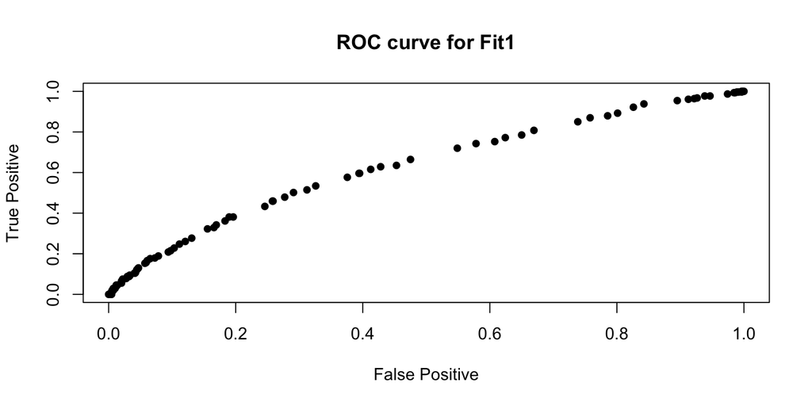

ROC plots represent the trade-off models face between sensitivity and specificity, that is to say, how well it can correctly classify vs how often it produces a false positive. In a sense, we can use the area under this curve as one possible estimate of how good our model is. This is illustrated by the plot above.

We can also use select an appropriate threshold, given our criteria by plotting the False positives vs the thresholds.

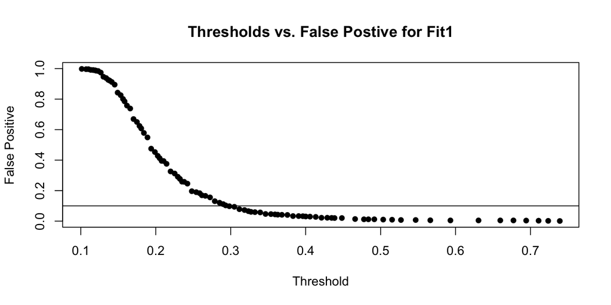

In this case, is we want a classifier that has at most a false positive rate of 0.1, we can select a threshold of 0.3.

2. Overlay two ROC curves: one from `fit1`, the other from `fit2`. Does one curve always contain the other curve? Is the AUC of one curve always larger than the AUC of the other one? Why or why not?

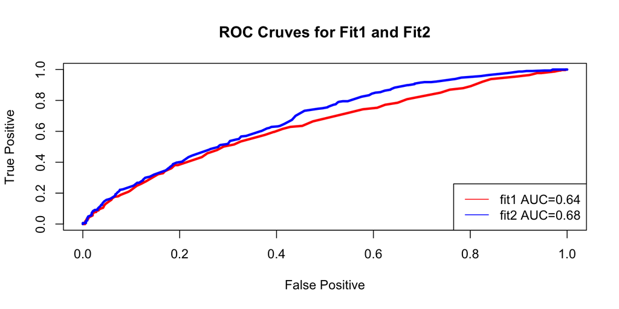

In this specific case, Fit2 will always have a larger AUC than Fit1 because it has more variables (while including the variables already in Fit1). Our classifier can only be as or more accurate with more complexity (as long as Fit2 includes all the variables of Fit1 and more). The more complex model will always overlap or contain the curve of the less complex model under these conditions.

3. Estimate the Positive Prediction Values and Negative Prediction Values for `fit1` and `fit2` using .5 as a threshold. Which model is more desirable if we prioritize the Positive Prediction values?

First, we’ll derive the confusion matrix and associated statistics for fit1:

```
## Confusion Matrix and Statistics
##
##           Reference
## Prediction    0    1
##          0 1075  298
##          1   11    9
##
##                Accuracy : 0.778
##                  95% CI : (0.755, 0.8)
##     No Information Rate : 0.78
##     P-Value [Acc > NIR] : 0.566
##
##                   Kappa : 0.029
##
##  Mcnemar's Test P-Value : <2e-16
##
##             Sensitivity : 0.02932
##             Specificity : 0.98987
##          Pos Pred Value : 0.45000
##          Neg Pred Value : 0.78296
##              Prevalence : 0.22039
##          Detection Rate : 0.00646
##    Detection Prevalence : 0.01436
##       Balanced Accuracy : 0.50959
##
##        'Positive' Class : 1
##
```

Now, we’ll do the same for fit2:

```
## Confusion Matrix and Statistics
##
##           Reference
## Prediction    0    1
##          0 1067  290
##          1   19   17
##
##                Accuracy : 0.778
##                  95% CI : (0.755, 0.8)
##     No Information Rate : 0.78
##     P-Value [Acc > NIR] : 0.566
##
##                   Kappa : 0.055
##
##  Mcnemar's Test P-Value : <2e-16
##
##             Sensitivity : 0.0554
##             Specificity : 0.9825
##          Pos Pred Value : 0.4722
##          Neg Pred Value : 0.7863
##              Prevalence : 0.2204
##          Detection Rate : 0.0122
##    Detection Prevalence : 0.0258
##       Balanced Accuracy : 0.5189
##
##        'Positive' Class : 1
##
```

As we can see, if we prioritize positive prediction, at a threshold of 0.5, we should go with fit2, as it has a slightly higher positive prediction.

4. For `fit1`: overlay two curves, but put the threshold over the probability function as the x-axis and positive prediction values and the negative prediction values as the y-axis. Overlay the same plot for `fit2`. Which model would you choose if the set of positive and negative prediction values are the concerns? If you can find an R package to do so, you may use it directly.

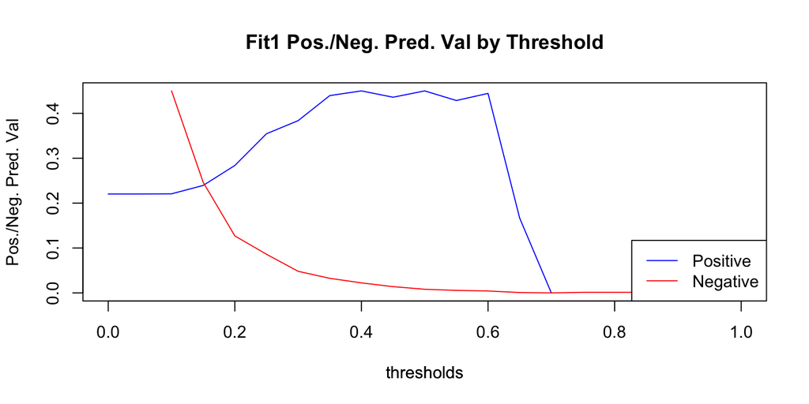

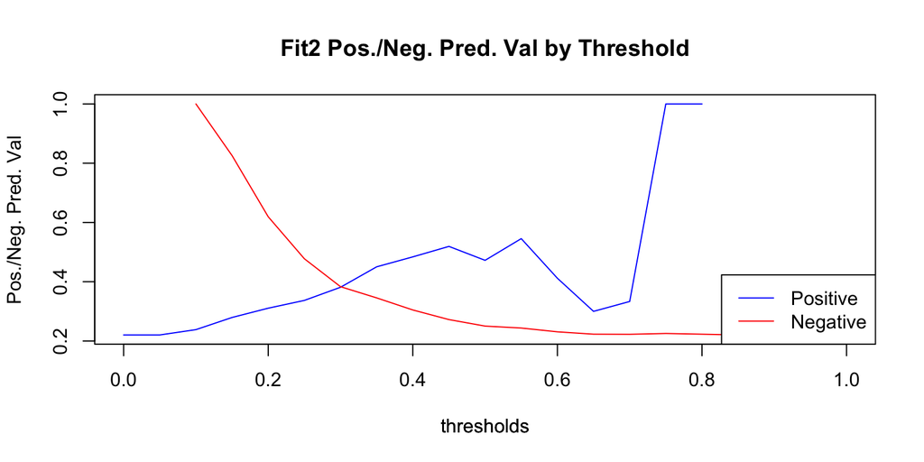

Based on the above plots, I would go with Fit2, in this case - as it can achieve a higher set of these values across thresholds.

### 2.1.5 Cost function/ Bayes Rule

Bayes rules with risk ratio $\frac{a_{10}}{a_{01}}=10$ or $\frac{a_{10}}{a_{01}}=1$. Use your final model obtained from Part 1 to build a class of linear classifiers.

1. Write down the linear boundary for the Bayes classifier if the risk ratio of $a_{10}/a_{01}=10$.

P̂(Y=1|x) >(0.1/1+0.1 ) =0 .0909

2. What is your estimated weighted misclassification error for this given risk ratio?

```
## [1] 0.719
```

The estimated MCE at the 10 to 1 risk ratio is: 0.719.

3. How would you classify Liz under this classifier?

Since earlier we saw that our final model gave Liz a a 3.36% probability of being diagnosed with heart disease, this classifier with a cutoff of ~9% would indicate that she does NOT fall into the HD category.

Now, draw two estimated curves where x = threshold, and y = misclassification errors, corresponding to the thresholding rule given in x-axis.

22. Use weighted misclassification error, and set $a_{10}/a_{01}=10$. How well does the Bayes rule classifier perform?

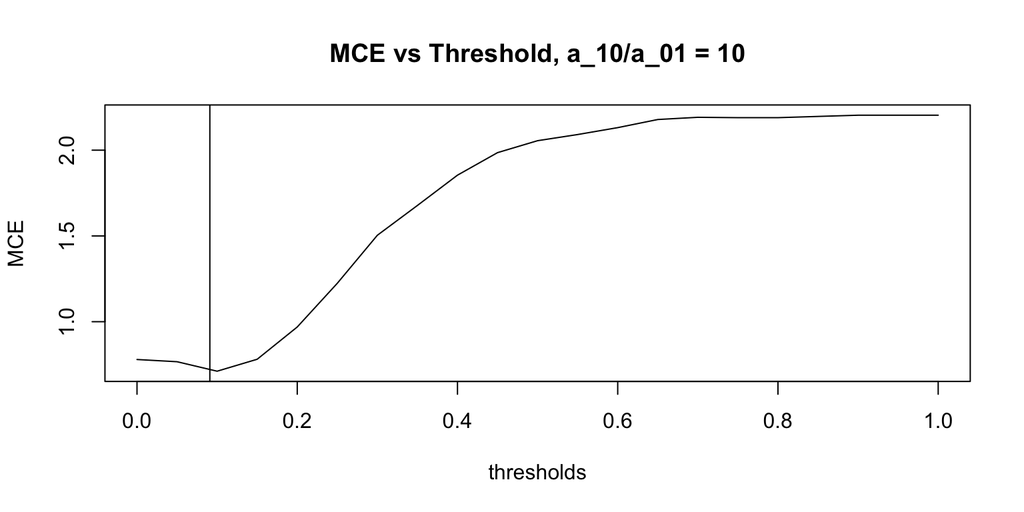

The vertical line describes the threshold cutoff given to us by the Bayesian method for the risk ratio 10/1. As we can see, under the assumption that a_10/a_01, the threshold given to us by Bayes rule does very well in finding the optimal threshold (0.0909) to minimize MCE.

6. Use weighted misclassification error, and set $a_{10}/a_{01}=1$. How well does the Bayes rule classifier perform?

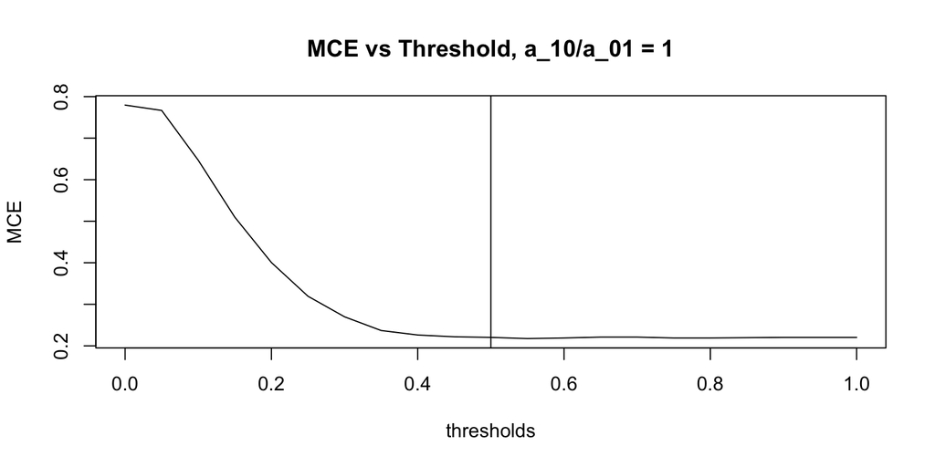

The vertical line describes the threshold cutoff given to us by the Bayesian method for the risk ratio 1/1. As we can see, Bayes rule does well at finding the threshold (0.5 in this case) at which the MCE is minimized, given the appropriate risk ratio. This is illustrated by the new threshold given the 1/1 ratio.

# 3 Part II: Project

## 3.1 Project Option 1 Credit Risk via LendingClub

## 3.2 Project Opetion 2 Diabetes and Health Management